# 16 - ANOSIM, SIMPER, and mvabund for Community Analysis

Francisco E. Fonturbel

05/October/2026

## How to analyze species composition?

Dealing with biodiversity data is somewhat different than dealing with the usual stuff that we are used to. Some people use standard approaches (e.g., ANOVA) to compare species composition among sites, but this is not correct as in this case the identity of the species matters, and traditional methods cannot consider them (species are not interchangeable).

### Understanding the Challenge

Traditional univariate tests (like ANOVA) have several limitations when applied to community data:

1. **Ignore species identities:** Treating each species independently loses the multivariate structure
2. **Multiple testing problem:** Testing each species separately inflates Type I error
3. **Ignore correlations:** Species often co-vary due to similar habitat requirements
4. **Compositional nature:** Community data has special properties (many zeros, over-dispersion)

### Loading and Exploring the Data

```r
#Loading packages
library(vegan)      # For ANOSIM and SIMPER
library(mvabund)    # For multivariate abundance analysis
library(ggplot2)    # For advanced plotting
library(dplyr)      # For data manipulation
library(tidyr)      # For data reshaping
library(corrplot)   # For correlation plots
library(nestedANOSIM) # For two-way ANOSIM and SIMPER (github.com/fonturbel/nestedANOSIM)

data<-read.table("data/16_bird_data.txt",
                     header=TRUE,
                     sep="\t", dec=".",
                     na.strings="NA")

# Check data structure
str(data)
```

```
## 'data.frame':    36 obs. of  22 variables:
##  $ Sample          : chr  "Point" "Point" "Point" "Point" ...
##  $ Habitat         : chr  "Native" "Plantation" "Secondary" "Secondary" ...
##  $ CACHUDITO       : int  1 0 0 0 0 0 0 0 2 2 ...
##  $ CARPINTERITO    : int  0 0 0 0 0 0 1 0 2 0 ...
##  $ CARPINTERO_NEGRO: int  0 0 0 0 0 0 0 0 0 1 ...
##  $ CHUCAO          : int  10 8 7 10 3 3 14 9 3 7 ...
##  $ CHUNCHO         : int  0 0 0 0 0 0 1 0 0 0 ...
##  $ CHURRIN         : int  0 2 0 0 0 2 4 2 1 3 ...
##  $ COLIBRI         : int  27 26 14 36 11 18 39 26 36 58 ...
##  $ COLILARGA       : int  1 0 0 0 0 0 2 1 0 4 ...
##  $ COMESEBO        : int  0 0 0 0 0 0 0 0 0 0 ...
##  $ COMETOCINO      : int  15 4 3 0 2 0 2 5 2 0 ...
##  $ DIUCON          : int  2 4 0 1 0 0 1 0 0 1 ...
##  $ FIOFIO          : int  5 10 1 11 7 1 5 9 16 6 ...
##  $ HUETHUET        : int  3 1 1 2 1 0 3 2 4 0 ...
##  $ JILGUERO        : int  0 0 0 0 0 0 0 0 1 4 ...
##  $ PITIO           : int  1 0 0 0 0 0 2 0 0 1 ...
##  $ RAYADITO        : int  17 7 3 12 2 4 10 8 12 2 ...
##  $ TIJERAL         : int  1 0 0 0 0 0 0 0 0 0 ...
##  $ TORCAZA         : int  0 0 0 7 1 1 0 0 5 5 ...
##  $ TORDO           : int  0 0 0 2 0 3 0 0 0 3 ...
##  $ ZORZAL          : int  0 0 0 3 0 0 3 2 7 7 ...
```

```r
head(data)
```

```
##   Sample    Habitat CACHUDITO CARPINTERITO CARPINTERO_NEGRO CHUCAO CHUNCHO
## 1  Point     Native         1            0                0     10       0
## 2  Point Plantation         0            0                0      8       0
## 3  Point  Secondary         0            0                0      7       0
## 4  Point  Secondary         0            0                0     10       0
## 5  Point Plantation         0            0                0      3       0
## 6  Point Plantation         0            0                0      3       0
##   CHURRIN COLIBRI COLILARGA COMESEBO COMETOCINO DIUCON FIOFIO HUETHUET JILGUERO
## 1       0      27         1        0         15      2      5        3        0
## 2       2      26         0        0          4      4     10        1        0
## 3       0      14         0        0          3      0      1        1        0
## 4       0      36         0        0          0      1     11        2        0
## 5       0      11         0        0          2      0      7        1        0
## 6       2      18         0        0          0      0      1        0        0
##   PITIO RAYADITO TIJERAL TORCAZA TORDO ZORZAL
## 1     1       17       1       0     0      0
## 2     0        7       0       0     0      0
## 3     0        3       0       0     0      0
## 4     0       12       0       7     2      3
## 5     0        2       0       1     0      0
## 6     0        4       0       1     3      0
```

```r
# Summary of experimental design
print("Sample sizes by habitat:")
```

```
## [1] "Sample sizes by habitat:"
```

```r
table(data$Habitat)
```

```
##
##     Logged     Native Plantation  Secondary
##          9          9          9          9
```

```r
print("Sample sizes by sampling method:")
```

```
## [1] "Sample sizes by sampling method:"
```

```r
table(data$Sample)
```

```
##
## Camera1 Camera2   Point
##      12      12      12
```

```r
print("Cross-tabulation:")
```

```
## [1] "Cross-tabulation:"
```

```r
table(data$Sample, data$Habitat)
```

```
##
##           Logged Native Plantation Secondary
##   Camera1      3      3          3         3
##   Camera2      3      3          3         3
##   Point        3      3          3         3
```

We will use the data of [Fontúrbel et al. 2020](https://www.sciencedirect.com/science/article/pii/S1470160X20308013) to illustrate this. This dataset contains bird abundance data for camera trap and point count data, comparing four habitat conditions.

### Data Exploration

```r
# Extract species data
birds<-data[,3:22]

# Basic summaries
print("Total abundance per species:")
```

```
## [1] "Total abundance per species:"
```

```r
colSums(birds)
```

```
##        CACHUDITO     CARPINTERITO CARPINTERO_NEGRO           CHUCAO
##                6                7                6              182
##          CHUNCHO          CHURRIN          COLIBRI        COLILARGA
##               10               25              558               40
##         COMESEBO       COMETOCINO           DIUCON           FIOFIO
##               20               42                9              160
##         HUETHUET         JILGUERO            PITIO         RAYADITO
##               68                8                9              231
##          TIJERAL          TORCAZA            TORDO           ZORZAL
##                7               34               18              146
```

```r
print("Total abundance per site:")
```

```
## [1] "Total abundance per site:"
```

```r
rowSums(birds)
```

```
##  [1]  83  62  29  84  27  32  87  64  91 104  70  70  27  39   7  42  17   4  36
## [20]  32  11  43  15  36  70  32  28  26  17   5 139  25  50  27  16  39
```

```r
# Species richness per site
richness <- rowSums(birds > 0)
print("Species richness summary:")
```

```
## [1] "Species richness summary:"
```

```r
summary(richness)
```

```
##    Min. 1st Qu.  Median    Mean 3rd Qu.    Max.
##   3.000   6.000   7.000   7.583   9.000  14.000
```

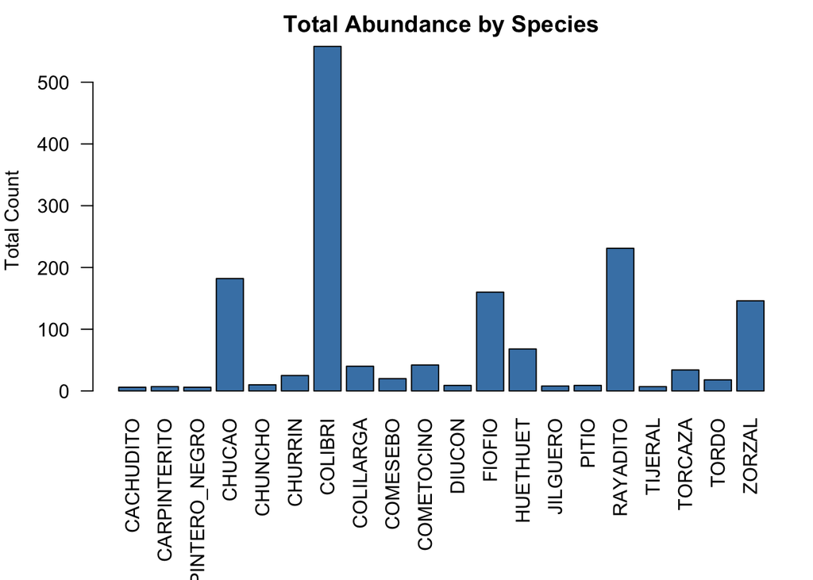

```r
# Visualize total abundances
par(mar=c(8,4,2,1))
barplot(colSums(birds), las=2, col="steelblue",
        main="Total Abundance by Species",
        ylab="Total Count")
```

### Visualizing Community Composition

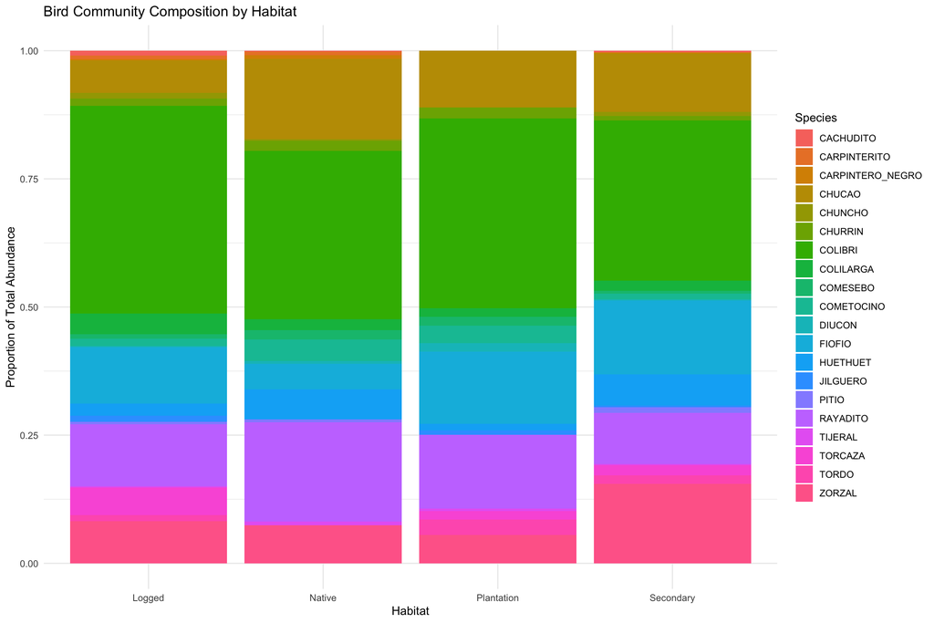

```r
# Prepare data for stacked barplot
birds_with_groups <- cbind(data[,1:2], birds)

# Get the species column names (all columns except Sample and Habitat)
species_cols <- names(birds)

# Calculate proportions by habitat
habitat_composition <- birds_with_groups %>%
  group_by(Habitat) %>%
  summarise(across(all_of(species_cols), sum)) %>%
  pivot_longer(cols = -Habitat, names_to = "Species", values_to = "Abundance")

# Stacked barplot by habitat
ggplot(habitat_composition, aes(x=Habitat, y=Abundance, fill=Species)) +
  geom_bar(stat="identity", position="fill") +
  labs(title="Bird Community Composition by Habitat",
       y="Proportion of Total Abundance") +
  theme_minimal() +
  theme(legend.position="right")
```

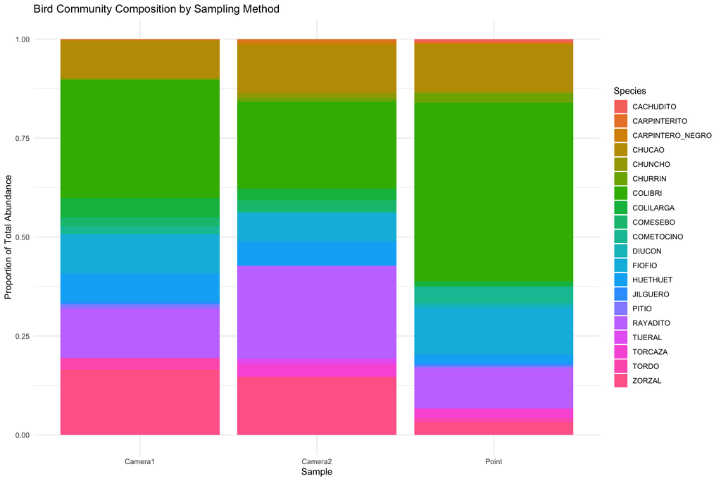

```r
# Calculate proportions by sampling method
sample_composition <- birds_with_groups %>%
  group_by(Sample) %>%
  summarise(across(all_of(species_cols), sum)) %>%
  pivot_longer(cols = -Sample, names_to = "Species", values_to = "Abundance")

# Stacked barplot by sampling method
ggplot(sample_composition, aes(x=Sample, y=Abundance, fill=Species)) +
  geom_bar(stat="identity", position="fill") +
  labs(title="Bird Community Composition by Sampling Method",
       y="Proportion of Total Abundance") +
  theme_minimal() +
  theme(legend.position="right")
```

## Analysis of Similarities (ANOSIM)

When we have species presence/absence or relative abundance data with two or more groups and at least three replicates per group, we can use the Analysis of Similarities (ANOSIM) to test for species composition differences. ANOSIM is a non-parametric approach that uses a similarity metric (e.g., Jaccard or Bray-Curtis) to compare species similarity within and between groups (following the same logic than ANOVA).

### Understanding ANOSIM

**How ANOSIM works:** 1. Calculate a dissimilarity matrix between all pairs of samples 2. Rank all dissimilarities 3. Compare average ranks within groups vs. between groups 4. Test significance using permutations

**The R statistic:** - R ranges from -1 to +1 - R ≈ 0: No difference between groups - R = 1: Complete separation (all within-group dissimilarities < all between-group) - R < 0: Within-group dissimilarities > between-group (rare, suggests misclassification)

**Interpretation guidelines:** - R > 0.75: Well separated - R > 0.5: Separated but overlapping - R > 0.25: Separated but strongly overlapping - R < 0.25: Barely separable

The resulting statistic (R) is not a proportional value as it is calculated upon rankings (and it should not be interpreted as a linear scale of difference). The significance of this test is estimated using permutations (P value is the number of times that the randomized R value is equal or greater than the real R value, divided by the number of permutations). ANOSIM is implemented in the `vegan` package.

### ANOSIM: Testing Habitat Effects

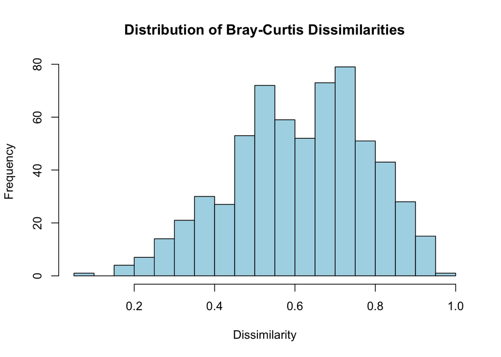

```r
#Creating a distance matrix
birdist<-vegdist(birds, method="bray")

# Check the distribution of dissimilarities
hist(birdist, main="Distribution of Bray-Curtis Dissimilarities",
     xlab="Dissimilarity", col="lightblue", breaks=20)
```

```r
#ANOSIM per habitat
# birdist is already a Bray-Curtis matrix, so anosim() needs no 'distance' argument
forestbirds<-anosim(birdist, data$Habitat, permutations = 999)
summary(forestbirds)
```

```
##
## Call:
## anosim(x = birdist, grouping = data$Habitat, permutations = 999)
## Dissimilarity: bray
##
## ANOSIM statistic R: 0.03497
##       Significance: 0.182
##
## Permutation: free
## Number of permutations: 999
##
## Upper quantiles of permutations (null model):
##    90%    95%  97.5%    99%
## 0.0559 0.0722 0.0962 0.1136
##
## Dissimilarity ranks between and within classes:
##              0%     25%    50%     75%  100%   N
## Between     1.0 164.375 318.75 474.250 630.0 486
## Logged     30.0 175.875 327.00 496.125 595.0  36
## Native      2.0  92.125 207.50 327.000 598.0  36
## Plantation 37.0 136.750 327.50 556.625 619.0  36
## Secondary  19.5 206.250 419.25 493.875 603.5  36
```

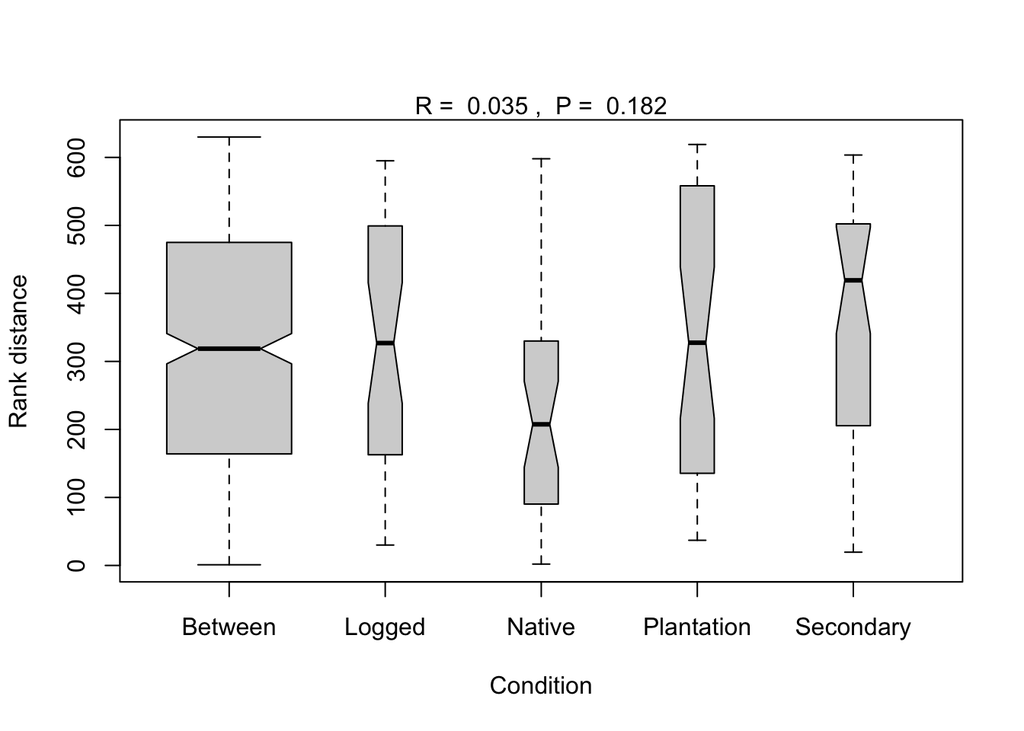

```r
plot(forestbirds, xlab="Condition", ylab="Rank distance")
```

```r
# Additional information
print(paste("ANOSIM R statistic:", round(forestbirds$statistic, 3)))
```

```
## [1] "ANOSIM R statistic: 0.035"
```

```r
print(paste("Significance:", forestbirds$signif))
```

```
## [1] "Significance: 0.182"
```

```r
print("Interpretation: R < 0.25 suggests communities are barely separable by habitat")
```

```
## [1] "Interpretation: R < 0.25 suggests communities are barely separable by habitat"
```

So, there is no significant difference among habitat conditions (R = 0.035, p = 0.182). This suggests that bird communities are similar across the different habitat types sampled.

### ANOSIM: Testing Sampling Method Effects

What about sampling approaches?

```r
sampbirds<-anosim(birdist, data$Sample, permutations = 999)
summary(sampbirds)
```

```
##
## Call:
## anosim(x = birdist, grouping = data$Sample, permutations = 999)
## Dissimilarity: bray
##
## ANOSIM statistic R: 0.2712
##       Significance: 0.001
##
## Permutation: free
## Number of permutations: 999
##
## Upper quantiles of permutations (null model):
##    90%    95%  97.5%    99%
## 0.0543 0.0733 0.0904 0.1222
##
## Dissimilarity ranks between and within classes:
##         0%     25%    50%     75% 100%   N
## Between  2 192.750 347.50 496.250  629 432
## Camera1 17 178.875 312.75 449.250  630  66
## Camera2 29 221.000 383.50 488.625  627  66
## Point    1  19.875  58.50 162.500  337  66
```

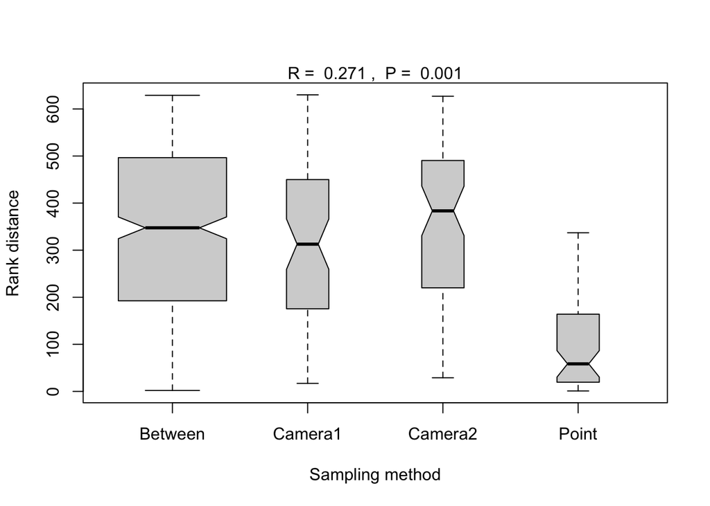

```r
plot(sampbirds, xlab="Sampling method", ylab="Rank distance")
```

```r
print(paste("ANOSIM R statistic:", round(sampbirds$statistic, 3)))
```

```
## [1] "ANOSIM R statistic: 0.271"
```

```r
print(paste("Significance:", sampbirds$signif))
```

```
## [1] "Significance: 0.001"
```

```r
print("Interpretation: R > 0.25 suggests some separation between sampling methods")
```

```
## [1] "Interpretation: R > 0.25 suggests some separation between sampling methods"
```

In this case, we found a significant difference (R = 0.271, p = 0.001), in which point counts are different from camera traps. This makes biological sense as different sampling methods may detect different species or relative abundances.

### Two-way ANOSIM: habitat within each sampling method

The two tests above look at one factor at a time, but our design has two: **habitat** (4 levels) and **sampling method** (3 levels), with 3 sites per habitat. Both factors are **crossed**: every habitat was sampled with every method. Since sampling method has a strong effect, it could be hiding a habitat effect. A two-way ANOSIM answers this by testing sampling method first and then habitat *within* each sampling method separately.

`vegan` only implements one-way ANOSIM, so we will use the `nested_anosim()` function from the `nestedANOSIM` package (avaiable from GitHub, install it with `remotes::install_github("fonturbel/nestedANOSIM")`). It runs three tests on the same Bray-Curtis matrix:

1. An overall test on the combined method x habitat groups.
2. A test of the main factor (sampling method).
3. A test of the second factor (habitat) within each level of the main factor, with a correction for multiple tests (`p_adjust`).

There is one more detail. The **same 12 sites** were sampled with point counts and, in two consecutive years, with camera traps (`Camera1` = first year, `Camera2` = second year), so the three samples from a site are not independent (they are *paired*). To account for this, we restrict the permutations of the sampling-method test to happen *within* each site using the `strata` argument. Within a single method each site appears only once, so the habitat tests use ordinary permutations.

```r
# Site ID: the same 12 sites (rows 1-12) were sampled with each method
site <- paste0("S", rep(1:12, 3))
table(site, data$Sample)[1:3, ]   # each site appears once per method
```

```
##
## site  Camera1 Camera2 Point
##   S1        1       1     1
##   S10       1       1     1
##   S11       1       1     1
```

```r
birds2 <- nested_anosim(comm   = birds,
                        main   = data$Sample,    # main factor
                        nested = data$Habitat,   # tested within each method
                        strata = site,           # paired design: permute within sites
                        method = "bray",
                        permutations = 9999,
                        p_adjust = "holm",       # we run 3 habitat tests
                        seed = 123)
```

```
## === NESTED (TWO-WAY) ANOSIM ===
## Dissimilarity: bray | permutations: 9999 | p-adjust (within-level tests): holm
## Samples analysed: 36
##
## 1. OVERALL TEST (main.nested combined)
##    R = 0.1731 | p = 0.0164 *
##
## 2. MAIN FACTOR (permutations within strata)
##    R = 0.2712 | p = 0.0001 ***
##
## 3. SECOND FACTOR WITHIN EACH MAIN-FACTOR LEVEL
##    Camera1 (Logged=3, Native=3, Plantation=3, Secondary=3)
##       R = 0.0046 | p = 0.4515 | p_adj = 0.9030 ns
##    Camera2 (Logged=3, Native=3, Plantation=3, Secondary=3)
##       R = -0.1914 | p = 0.9289 | p_adj = 0.9289 ns
##    Point (Logged=3, Native=3, Plantation=3, Secondary=3)
##       R = 0.1312 | p = 0.1577 | p_adj = 0.4731 ns
##
## 4. GROUP SUMMARY
##               Group N_samples Mean_richness Mean_abundance
##      Camera1.Logged         3      7.333333       23.00000
##      Camera1.Native         3      6.666667       31.66667
##  Camera1.Plantation         3      6.333333       20.00000
##   Camera1.Secondary         3      7.333333       28.33333
##      Camera2.Logged         3      5.666667       31.00000
##      Camera2.Native         3      8.333333       78.00000
##  Camera2.Plantation         3      4.333333       18.00000
##   Camera2.Secondary         3      6.333333       31.00000
##        Point.Logged         3     11.666667       88.33333
##        Point.Native         3     11.000000       78.00000
##    Point.Plantation         3      7.333333       40.33333
##     Point.Secondary         3      8.666667       61.00000
##
## R near 1: groups well separated | R near 0: no separation | R < 0: within-group dissimilarities exceed between-group ones.
## Significance: *** p<=0.001, ** p<=0.01, * p<=0.05, ns = not significant
```

The effect of sampling method holds after accounting for the paired design (R = 0.271, p = 0.0001). However, habitat has no effect even when we compare habitats within the same sampling method:

```r
birds2$nested
```

```
##   main_level n_groups n_samples                                   group_sizes
## 1    Camera1        4        12 Logged=3, Native=3, Plantation=3, Secondary=3
## 2    Camera2        4        12 Logged=3, Native=3, Plantation=3, Secondary=3
## 3      Point        4        12 Logged=3, Native=3, Plantation=3, Secondary=3
##             R      p note  p_adj
## 1  0.00462963 0.4515      0.9030
## 2 -0.19135802 0.9289      0.9289
## 3  0.13117284 0.1577      0.4731
```

Notice the **negative R** within `Camera2` (R = -0.191): dissimilarities among sites of the same habitat are *larger* than those between habitats. Also keep in mind that we only have 3 sites per habitat and method, so these tests have little statistical power: a non-significant result does not prove that habitats are identical.

The `plot_anosim_box()` function draws the ANOSIM boxplots with `ggplot2`. It accepts a two-way result (choosing the test with `which`) or a regular `anosim` object:

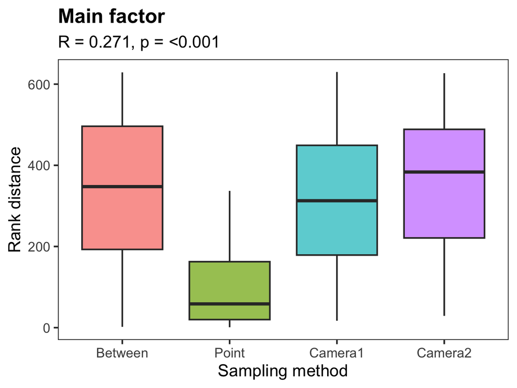

```r
plot_anosim_box(birds2, which = "main", xlab = "Sampling method")
```

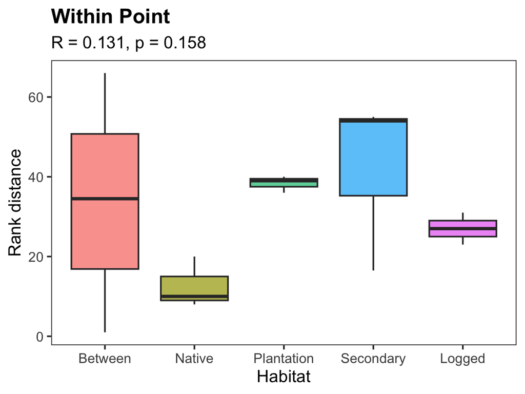

```r
plot_anosim_box(birds2, which = "Point", xlab = "Habitat")
```

Which factor goes first depends on the question. Here we asked whether habitat matters once we control for the sampling method. If we wanted to know whether the sampling methods differ within each habitat, we would use `main = data$Habitat` and `nested = data$Sample` instead.

## Which species explain the differences?

In the second case, we found a significant difference in the ANOSIM test. But, which species account for such differences? In this case, we can use the Similarity Percentages (SIMPER) test, also implemented in the `vegan` package.

### Understanding SIMPER

**SIMPER (Similarity Percentages) analysis:** - Identifies species contributing most to observed differences between groups - Calculates average contribution of each species to dissimilarity - Provides cumulative contribution percentages - Helps focus on key species driving community patterns

```r
simbirds<-simper(birds, group = data$Sample, permutations = 999)
summary(simbirds, digits = 3)
```

```
##
## Contrast: Point_Camera1
##
##                  average      sd   ratio     ava     avb cumsum     p
## COLIBRI           0.2484  0.1199  2.0720 30.1700  7.6700   0.38 0.001 ***
## FIOFIO            0.0770  0.0538  1.4310  7.9200  2.5800   0.50 0.044 *
## CHUCAO            0.0743  0.0440  1.6890  8.0000  2.4200   0.62 0.252
## RAYADITO          0.0528  0.0412  1.2820  6.7500  3.2500   0.70 0.995
## ZORZAL            0.0447  0.0537  0.8330  2.1700  4.2500   0.77 0.969
## COMETOCINO        0.0313  0.0389  0.8050  2.8300  0.5000   0.82 0.001 ***
## HUETHUET          0.0205  0.0185  1.1070  1.4200  1.8300   0.85 0.974
## CHURRIN           0.0168  0.0143  1.1780  1.5800  0.0800   0.87 0.001 ***
## COLILARGA         0.0161  0.0182  0.8840  0.9200  1.2500   0.90 0.882
## TORCAZA           0.0155  0.0218  0.7120  1.5800  0.0000   0.92 0.657
## TORDO             0.0131  0.0168  0.7780  0.6700  0.7500   0.94 0.317
## DIUCON            0.0076  0.0134  0.5700  0.7500  0.0000   0.96 0.001 ***
## COMESEBO          0.0061  0.0086  0.7050  0.0000  0.5800   0.96 0.992
## JILGUERO          0.0054  0.0091  0.5930  0.5000  0.1700   0.97 0.221
## PITIO             0.0052  0.0067  0.7810  0.4200  0.2500   0.98 0.510
## CACHUDITO         0.0044  0.0066  0.6660  0.5000  0.0000   0.99 0.001 ***
## CHUNCHO           0.0032  0.0066  0.4860  0.2500  0.0800   0.99 0.914
## CARPINTERITO      0.0028  0.0055  0.5040  0.2500  0.0800   1.00 0.701
## CARPINTERO_NEGRO  0.0015  0.0035  0.4340  0.1700  0.0000   1.00 0.665
## TIJERAL           0.0008  0.0026  0.2980  0.0800  0.0000   1.00 0.992
## ---
## Signif. codes:  0 '***' 0.001 '**' 0.01 '*' 0.05 '.' 0.1 ' ' 1
##
## Contrast: Point_Camera2
##
##                  average      sd   ratio     ava     avb cumsum     p
## COLIBRI           0.2244  0.1153  1.9470 30.1700  8.6700   0.35 0.006 **
## CHUCAO            0.0809  0.0459  1.7650  8.0000  4.7500   0.47 0.052 .
## RAYADITO          0.0668  0.0510  1.3110  6.7500  9.2500   0.58 0.850
## FIOFIO            0.0630  0.0487  1.2930  7.9200  2.8300   0.68 0.605
## ZORZAL            0.0467  0.0449  1.0400  2.1700  5.7500   0.75 0.958
## COMETOCINO        0.0287  0.0368  0.7810  2.8300  0.1700   0.79 0.012 *
## HUETHUET          0.0259  0.0323  0.8020  1.4200  2.4200   0.83 0.842
## TORCAZA           0.0226  0.0333  0.6800  1.5800  1.2500   0.87 0.260
## CHURRIN           0.0163  0.0134  1.2160  1.5800  0.4200   0.89 0.001 ***
## COLILARGA         0.0135  0.0150  0.8980  0.9200  1.1700   0.91 0.970
```

[output cut: 25 more lines]

```
## TORDO             0.0140 0.0217 0.6430 0.7500 0.0800   0.93 0.232
## CHUNCHO           0.0096 0.0205 0.4680 0.0800 0.5000   0.94 0.075 .
## COMETOCINO        0.0089 0.0131 0.6770 0.5000 0.1700   0.96 1.000
## TIJERAL           0.0073 0.0113 0.6450 0.0000 0.5000   0.97 0.001 ***
## PITIO             0.0056 0.0103 0.5420 0.2500 0.0800   0.98 0.367
## CARPINTERITO      0.0037 0.0094 0.3920 0.0800 0.2500   0.98 0.482
## CHURRIN           0.0037 0.0091 0.4050 0.0800 0.4200   0.99 0.999
## CARPINTERO_NEGRO  0.0036 0.0120 0.2970 0.0000 0.3300   1.00 0.533
## JILGUERO          0.0031 0.0077 0.3980 0.1700 0.0000   1.00 0.799
## CACHUDITO         0.0000 0.0000    NaN 0.0000 0.0000   1.00    NA
## DIUCON            0.0000 0.0000    NaN 0.0000 0.0000   1.00    NA
## ---
## Signif. codes:  0 '***' 0.001 '**' 0.01 '*' 0.05 '.' 0.1 ' ' 1
## Permutation: free
## Number of permutations: 999
```

```r
# The comparisons are named after the groups, in order of appearance in the data
names(simbirds)
```

```
## [1] "Point_Camera1"   "Point_Camera2"   "Camera1_Camera2"
```

The output of `summary()` is a list with one table per pair of groups, which is not very convenient to work with. The `nested_simper()` function from `nestedANOSIM` returns the same results as a single tidy data frame. It uses the same design as the two-way ANOSIM: the main factor (sampling method, permuting within sites) and the second factor (habitat) within each sampling method. By default it keeps the species that together explain 70% of the dissimilarity (`cutoff = 0.7`):

```r
simbirds2 <- nested_simper(comm   = birds,
                           main   = data$Sample,
                           nested = data$Habitat,
                           strata = site,          # paired design, as in the ANOSIM
                           permutations = 999,
                           cutoff = 0.7,
                           seed = 123)
```

```
## === NESTED (TWO-WAY) SIMPER ===
## Bray-Curtis | permutations: 999 | taxa shown up to 70% of the dissimilarity
## Samples analysed: 36
## Note: with more than two groups, taxon p-values are computed by permuting all groups,
##       so each pair's p-values also depend on the other groups (see ?nested_simper).
##
## 1. MAIN FACTOR (permutations within strata)
##
##    Point vs Camera1 (average dissimilarity = 0.648)
##   species    pct cum_pct mean_A mean_B     p
##   COLIBRI 38.361  38.361 30.167  7.667 0.001
##    FIOFIO 11.891  50.253  7.917  2.583 0.013
##    CHUCAO 11.469  61.722  8.000  2.417 0.197
##  RAYADITO  8.155  69.877  6.750  3.250 0.997
##    ZORZAL  6.908  76.785  2.167  4.250 0.962
##
##    Point vs Camera2 (average dissimilarity = 0.645)
##   species    pct cum_pct mean_A mean_B     p
##   COLIBRI 34.806  34.806 30.167  8.667 0.010
##    CHUCAO 12.555  47.361  8.000  4.750 0.013
##  RAYADITO 10.363  57.724  6.750  9.250 0.824
##    FIOFIO  9.769  67.493  7.917  2.833 0.607
##    ZORZAL  7.241  74.734  2.167  5.750 0.943
##
##    Camera1 vs Camera2 (average dissimilarity = 0.634)
##   species    pct cum_pct mean_A mean_B     p
##   COLIBRI 21.587  21.587  7.667  8.667 0.998
##  RAYADITO 16.695  38.282  3.250  9.250 0.001
##    ZORZAL 14.277  52.559  4.250  5.750 0.003
##    CHUCAO 10.427  62.986  2.417  4.750 0.661
##    FIOFIO  9.703  72.690  2.583  2.833 0.697
##
## 2. SECOND FACTOR WITHIN EACH MAIN-FACTOR LEVEL
##
##  Camera1 (Logged=3, Native=3, Plantation=3, Secondary=3)
##
##    Native vs Plantation (average dissimilarity = 0.631)
##   species    pct cum_pct mean_A mean_B     p
##   COLIBRI 39.483  39.483 15.000  4.333 0.080
##    CHUCAO 13.106  52.588  3.667  3.667 0.217
```

[output cut: 132 more lines]

```
##    FIOFIO  9.176  52.528  6.000 10.000 0.588
##    ZORZAL  8.360  60.888  0.000  5.333 0.006
##    CHUCAO  6.475  67.363  4.667  7.000 0.600
##  RAYADITO  6.370  73.733  4.333  5.667 0.916
##
##    Secondary vs Logged (average dissimilarity = 0.37)
##   species    pct cum_pct mean_A mean_B     p
##   COLIBRI 35.188  35.188 27.000 44.667 0.347
##    FIOFIO 12.705  47.893  9.333 10.000 0.507
##  RAYADITO  8.494  56.388  5.333  5.667 0.918
##    ZORZAL  7.264  63.651  1.667  5.333 0.093
##    CHUCAO  6.280  69.932  9.333  7.000 0.886
##   TORCAZA  6.211  76.143  2.333  3.333 0.195
##
## pct: % of the average dissimilarity | mean_A, mean_B: mean abundance in the first and second group of each comparison.
```

```r
# Tidy table for the sampling methods: one row per species and comparison
simbirds2$main[, c("comparison", "species", "pct", "cum_pct", "mean_a", "mean_b", "p")]
```

```
##            comparison  species       pct  cum_pct    mean_a   mean_b     p
## 1    Point vs Camera1  COLIBRI 38.361285 38.36128 30.166667 7.666667 0.001
## 2    Point vs Camera1   FIOFIO 11.891493 50.25278  7.916667 2.583333 0.013
## 3    Point vs Camera1   CHUCAO 11.469344 61.72212  8.000000 2.416667 0.197
## 4    Point vs Camera1 RAYADITO  8.155019 69.87714  6.750000 3.250000 0.997
## 5    Point vs Camera1   ZORZAL  6.907851 76.78499  2.166667 4.250000 0.962
## 6    Point vs Camera2  COLIBRI 34.805818 34.80582 30.166667 8.666667 0.010
## 7    Point vs Camera2   CHUCAO 12.555098 47.36092  8.000000 4.750000 0.013
## 8    Point vs Camera2 RAYADITO 10.363081 57.72400  6.750000 9.250000 0.824
## 9    Point vs Camera2   FIOFIO  9.769369 67.49337  7.916667 2.833333 0.607
## 10   Point vs Camera2   ZORZAL  7.240829 74.73420  2.166667 5.750000 0.943
## 11 Camera1 vs Camera2  COLIBRI 21.587348 21.58735  7.666667 8.666667 0.998
## 12 Camera1 vs Camera2 RAYADITO 16.695146 38.28249  3.250000 9.250000 0.001
## 13 Camera1 vs Camera2   ZORZAL 14.276721 52.55921  4.250000 5.750000 0.003
## 14 Camera1 vs Camera2   CHUCAO 10.427258 62.98647  2.416667 4.750000 0.661
## 15 Camera1 vs Camera2   FIOFIO  9.703107 72.68958  2.583333 2.833333 0.697
```

`pct` is the percentage of the average dissimilarity explained by each species, `cum_pct` is the cumulative percentage, and `mean_a` and `mean_b` are the mean abundances in the first and second group of each comparison. Being a data frame, it is easy to plot:

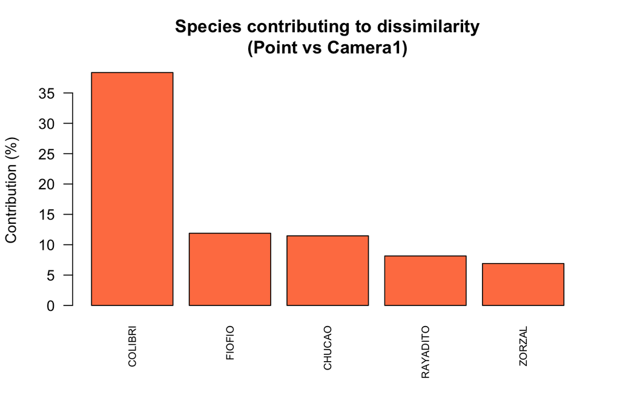

```r
top <- subset(simbirds2$main, comparison == "Point vs Camera1")
barplot(top$pct, names.arg = top$species, las = 2, col = "coral",
        main = "Species contributing to dissimilarity\n(Point vs Camera1)",
        ylab = "Contribution (%)", cex.names = 0.7)
```

The hummingbird (`COLIBRI`) alone explains about 38% of the difference between point counts and camera traps, as both methods detect it very differently.

SIMPER p-values must be read with care when there are more than two groups. To compute them, `vegan` permutes the labels of *all* groups, so the p-value of one pair is also affected by the other groups. For instance, several species look “significant” between the two camera years:

```r
cams <- subset(simbirds2$main, comparison == "Camera1 vs Camera2")
cams[, c("species", "pct", "mean_a", "mean_b", "p")]
```

```
##     species       pct   mean_a   mean_b     p
## 11  COLIBRI 21.587348 7.666667 8.666667 0.998
## 12 RAYADITO 16.695146 3.250000 9.250000 0.001
## 13   ZORZAL 14.276721 4.250000 5.750000 0.003
## 14   CHUCAO 10.427258 2.416667 4.750000 0.661
## 15   FIOFIO  9.703107 2.583333 2.833333 0.697
```

However, a pairwise ANOSIM shows that the two camera years do not differ as a whole:

```r
two_cams <- data$Sample != "Point"
set.seed(123)
cameras <- anosim(vegdist(birds[two_cams, ], method = "bray"),
                  data$Sample[two_cams], permutations = 9999,
                  strata = site[two_cams])
cameras
```

```
##
## Call:
## anosim(x = vegdist(birds[two_cams, ], method = "bray"), grouping = data$Sample[two_cams],      permutations = 9999, strata = site[two_cams])
## Dissimilarity: bray
##
## ANOSIM statistic R: -0.01426
##       Significance: 0.36963
##
## Blocks:  strata
## Permutation: free
## Number of permutations: 4095
```

The bird communities recorded by the cameras did not differ between years (R = -0.014, p = 0.37), so camera traps produced consistent results from one year to the next. The species-level p-values from SIMPER are therefore better used as a guide than as formal tests.

Keep in mind that SIMPER contributions are descriptive: abundant and highly variable species tend to dominate them (Warton et al. 2012, *Methods in Ecology and Evolution* 3: 89-101). This is one of the reasons to use model-based approaches such as `mvabund`, which we will see next.

## Multivariate Abundance Analysis using mvabund

While ANOSIM and SIMPER are useful, they have some limitations: - **ANOSIM:** Assumes exchangeability, sensitive to dispersion differences, uses rank-based approach - **Limited inference:** Doesn’t provide species-level p-values or account for mean-variance relationships

The `mvabund` package provides a more powerful alternative based on **multivariate generalized linear models (GLMs)** that: - **Tests community-level hypotheses** while accounting for species correlations - **Provides species-level inference** with proper p-value adjustment - **Handles mean-variance relationships** common in count data - **More powerful** for detecting subtle community differences - **Model-based approach** allowing for more complex experimental designs

### Understanding mvabund

**Key advantages of mvabund:**

1. **Proper statistical framework:** Uses likelihood-based models (GLMs) rather than distance-based approaches
2. **Accounts for mean-variance relationship:** Count data typically shows increasing variance with mean
3. **Species correlations:** Resampling approach accounts for correlations among species
4. **Hypothesis testing:** Provides proper multivariate test statistics
5. **Species-level inference:** Identifies which species contribute to differences with adjusted p-values
6. **Flexible:** Can include covariates and more complex designs

### Preparing Data for mvabund

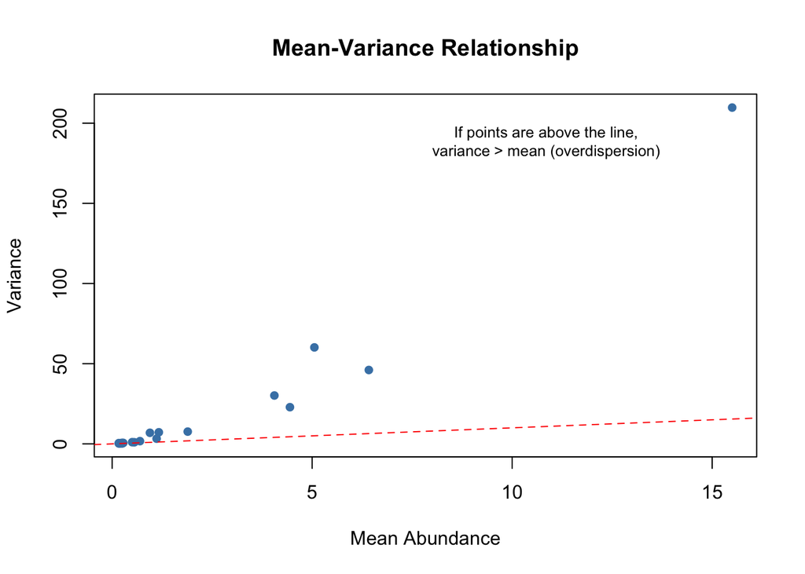

```r
# Create mvabund object
birds_mv <- mvabund(birds)

## Check the mean-variance relationship
# Alternative approach if meanvar.plot gives issues:
species_means <- colMeans(birds)
species_vars <- apply(birds, 2, var)

plot(species_means, species_vars,
     pch=16, col="steelblue",
     xlab="Mean Abundance",
     ylab="Variance",
     main="Mean-Variance Relationship")
abline(a=0, b=1, col="red", lty=2)  # 1:1 line
text(max(species_means)*0.7, max(species_vars)*0.9,
     "If points are above the line,\nvariance > mean (overdispersion)",
     cex=0.8)
```

```r
# The plot shows if variance increases with mean (common in count data)
# If variance increases with mean, negative binomial family is appropriate
```

### Choosing the Right Distribution Family

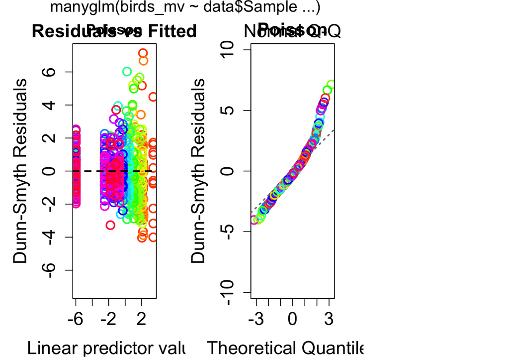

```r
# Compare different families for our data
# This helps us choose the appropriate error distribution

# Negative binomial is often best for count data with overdispersion
# Let's check by fitting models and comparing

# Fit models with different families
mod_poisson <- manyglm(birds_mv ~ data$Sample, family="poisson")
mod_negbin <- manyglm(birds_mv ~ data$Sample, family="negative.binomial")

# Plot residuals to check assumptions
par(mfrow=c(2,2))
plot(mod_poisson, which=1:2, main="Poisson")
```

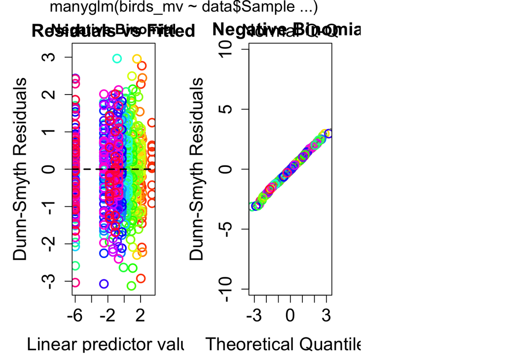

```r
plot(mod_negbin, which=1:2, main="Negative Binomial")
```

```r
par(mfrow=c(1,1))

print("Based on residual plots, negative binomial typically fits better for count data")
```

```
## [1] "Based on residual plots, negative binomial typically fits better for count data"
```

```r
print("We'll use negative binomial family for subsequent analyses")
```

```
## [1] "We'll use negative binomial family for subsequent analyses"
```

### mvabund Analysis: Testing Sampling Method Effects

```r
# Fit the model
mv_sample <- manyglm(birds_mv ~ data$Sample, family="negative.binomial")

# Summary of the model
summary(mv_sample)
```

```
##
## Test statistics:
##                    wald value Pr(>wald)
## (Intercept)            12.732     0.001 ***
## data$SampleCamera2      4.627     0.096 .
## data$SamplePoint        7.359     0.001 ***
## ---
## Signif. codes:  0 '***' 0.001 '**' 0.01 '*' 0.05 '.' 0.1 ' ' 1
##
## Test statistic:  9.387, p-value: 0.001
## Arguments:
##  Test statistics calculated assuming response assumed to be uncorrelated
##  P-value calculated using 999 resampling iterations via pit.trap resampling (to account for correlation in testing).
```

```r
# Hypothesis test using likelihood ratio test with resampling
# This tests if bird community composition differs by sampling method
mv_sample_test <- anova(mv_sample,
                        p.uni="adjusted",  # Get adjusted p-values for each species
                        nBoot=999,         # Number of bootstrap iterations
                        test="LR")         # Likelihood ratio test
```

```
## Time elapsed: 0 hr 0 min 2 sec
```

```r
print("Multivariate test results:")
```

```
## [1] "Multivariate test results:"
```

```r
print(mv_sample_test)
```

```
## Analysis of Deviance Table
##
## Model: birds_mv ~ data$Sample
##
## Multivariate test:
##             Res.Df Df.diff   Dev Pr(>Dev)
## (Intercept)     35
## data$Sample     33       2 132.6    0.001 ***
## ---
## Signif. codes:  0 '***' 0.001 '**' 0.01 '*' 0.05 '.' 0.1 ' ' 1
##
## Univariate Tests:
##             CACHUDITO          CARPINTERITO          CARPINTERO_NEGRO
##                   Dev Pr(>Dev)          Dev Pr(>Dev)              Dev Pr(>Dev)
## (Intercept)
## data$Sample    10.254    0.123         0.61    0.973            2.786    0.839
##             CHUCAO          CHUNCHO          CHURRIN          COLIBRI
##                Dev Pr(>Dev)     Dev Pr(>Dev)     Dev Pr(>Dev)     Dev Pr(>Dev)
## (Intercept)
## data$Sample  4.301    0.742   1.586    0.944   9.116    0.183  20.056    0.003
##             COLILARGA          COMESEBO          COMETOCINO          DIUCON
##                   Dev Pr(>Dev)      Dev Pr(>Dev)        Dev Pr(>Dev)    Dev
## (Intercept)
## data$Sample     0.196    0.973   11.832    0.067     13.106    0.039  12.72
##                      FIOFIO          HUETHUET          JILGUERO          PITIO
##             Pr(>Dev)    Dev Pr(>Dev)      Dev Pr(>Dev)      Dev Pr(>Dev)   Dev
## (Intercept)
## data$Sample    0.044  7.276    0.335    0.828    0.973    5.485    0.554 2.911
##                      RAYADITO          TIJERAL          TORCAZA          TORDO
##             Pr(>Dev)      Dev Pr(>Dev)     Dev Pr(>Dev)     Dev Pr(>Dev)   Dev
## (Intercept)
## data$Sample    0.839    7.768    0.286   7.324    0.335    6.67    0.411 4.301
##                      ZORZAL
##             Pr(>Dev)    Dev Pr(>Dev)
## (Intercept)
## data$Sample    0.742  3.505    0.820
## Arguments:
##  Test statistics calculated assuming uncorrelated response (for faster computation)
## P-value calculated using 999 iterations via PIT-trap resampling.
```

```r
# Interpret results
pval_sample <- mv_sample_test$table["data$Sample", "Pr(>Dev)"]
if(!is.na(pval_sample) && pval_sample < 0.05) {
  print("✓ Significant difference in community composition by sampling method")
} else if(!is.na(pval_sample)) {
  print("✗ No significant difference in community composition by sampling method")
} else {
  print("Note: P-value not available - check test results above")
}
```

```
## [1] "✓ Significant difference in community composition by sampling method"
```

### Species-Level Inference with mvabund

```r
# Get species-level p-values
species_pvals <- mv_sample_test$uni.p[2,]  # p-values for Sample effect
species_test <- mv_sample_test$uni.test[2,]  # Test statistics

# Create results table
species_results <- data.frame(
  Species = names(species_pvals),
  Test_Stat = species_test,
  P_value = species_pvals,
  Significant = ifelse(species_pvals < 0.05, "Yes", "No")
)

# Sort by p-value
species_results <- species_results[order(species_results$P_value),]

print("Species contributing to sampling method differences:")
```

```
## [1] "Species contributing to sampling method differences:"
```

```r
print(species_results)
```

```
##                           Species  Test_Stat P_value Significant
## COLIBRI                   COLIBRI 20.0556591   0.003         Yes
## COMETOCINO             COMETOCINO 13.1061765   0.039         Yes
## DIUCON                     DIUCON 12.7199155   0.044         Yes
## COMESEBO                 COMESEBO 11.8317724   0.067          No
## CACHUDITO               CACHUDITO 10.2542063   0.123          No
## CHURRIN                   CHURRIN  9.1161544   0.183          No
## RAYADITO                 RAYADITO  7.7675205   0.286          No
## FIOFIO                     FIOFIO  7.2762356   0.335          No
## TIJERAL                   TIJERAL  7.3244761   0.335          No
## TORCAZA                   TORCAZA  6.6704746   0.411          No
## JILGUERO                 JILGUERO  5.4846696   0.554          No
## CHUCAO                     CHUCAO  4.3012440   0.742          No
## TORDO                       TORDO  4.3006087   0.742          No
## ZORZAL                     ZORZAL  3.5054589   0.820          No
## CARPINTERO_NEGRO CARPINTERO_NEGRO  2.7864272   0.839          No
## PITIO                       PITIO  2.9110317   0.839          No
## CHUNCHO                   CHUNCHO  1.5864142   0.944          No
## CARPINTERITO         CARPINTERITO  0.6097609   0.973          No
## COLILARGA               COLILARGA  0.1962512   0.973          No
## HUETHUET                 HUETHUET  0.8280858   0.973          No
```

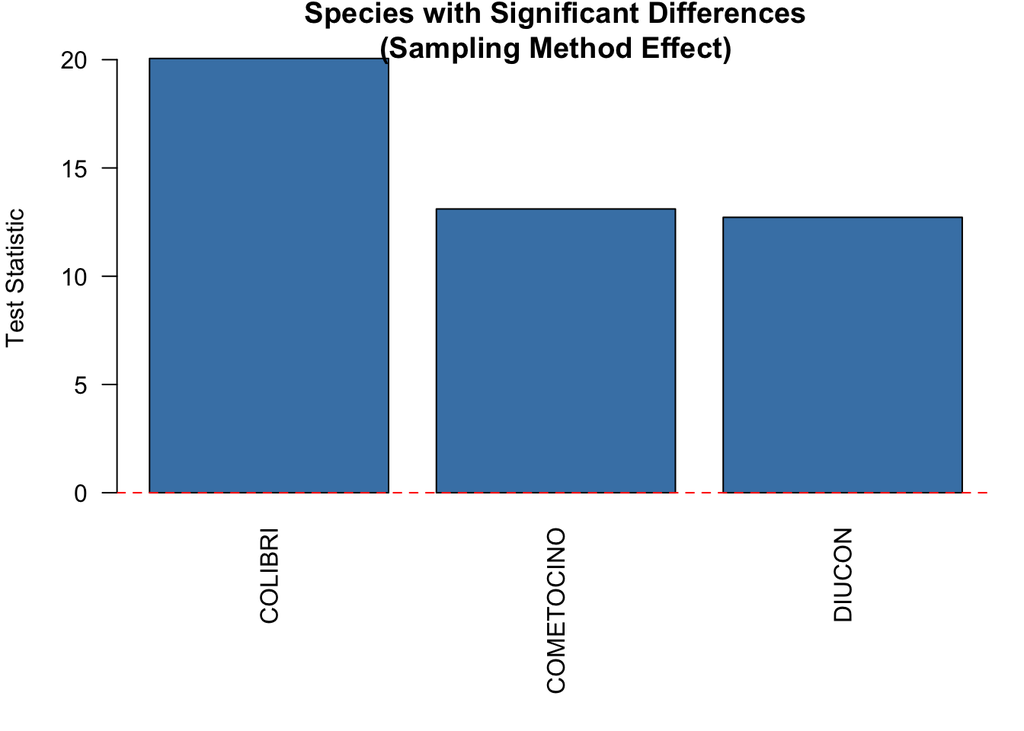

```r
# Visualize significant species
sig_species <- species_results[species_results$P_value < 0.05,]

if(nrow(sig_species) > 0) {
  par(mar=c(8,4,2,1))
  barplot(sig_species$Test_Stat,
          names.arg=sig_species$Species,
          las=2, col="steelblue",
          main="Species with Significant Differences\n(Sampling Method Effect)",
          ylab="Test Statistic")
  abline(h=0, col="red", lty=2)
  par(mar=c(5,4,4,2))
}
```

### mvabund Analysis: Testing Habitat Effects

```r
# Fit model for habitat
mv_habitat <- manyglm(birds_mv ~ data$Habitat, family="negative.binomial")

# Hypothesis test
mv_habitat_test <- anova(mv_habitat,
                        p.uni="adjusted",
                        nBoot=999,
                        test="LR")
```

```
## Time elapsed: 0 hr 0 min 3 sec
```

```r
print("Multivariate test results for Habitat:")
```

```
## [1] "Multivariate test results for Habitat:"
```

```r
print(mv_habitat_test)
```

```
## Analysis of Deviance Table
##
## Model: birds_mv ~ data$Habitat
##
## Multivariate test:
##              Res.Df Df.diff   Dev Pr(>Dev)
## (Intercept)      35
## data$Habitat     32       3 96.18    0.071 .
## ---
## Signif. codes:  0 '***' 0.001 '**' 0.01 '*' 0.05 '.' 0.1 ' ' 1
##
## Univariate Tests:
##              CACHUDITO          CARPINTERITO          CARPINTERO_NEGRO
##                    Dev Pr(>Dev)          Dev Pr(>Dev)              Dev Pr(>Dev)
## (Intercept)
## data$Habitat     4.226    0.969        6.227    0.859            2.746    0.991
##              CHUCAO          CHUNCHO          CHURRIN          COLIBRI
##                 Dev Pr(>Dev)     Dev Pr(>Dev)     Dev Pr(>Dev)     Dev Pr(>Dev)
## (Intercept)
## data$Habitat  5.119    0.928   3.721    0.978   1.585    0.991   3.612    0.978
##              COLILARGA          COMESEBO          COMETOCINO          DIUCON
##                    Dev Pr(>Dev)      Dev Pr(>Dev)        Dev Pr(>Dev)    Dev
## (Intercept)
## data$Habitat     3.317    0.978    2.998    0.978      4.723    0.934  1.338
##                       FIOFIO          HUETHUET          JILGUERO          PITIO
##              Pr(>Dev)    Dev Pr(>Dev)      Dev Pr(>Dev)      Dev Pr(>Dev)   Dev
## (Intercept)
## data$Habitat    0.991  1.482    0.991   12.322    0.170    4.753    0.934 5.858
##                       RAYADITO          TIJERAL          TORCAZA          TORDO
##              Pr(>Dev)      Dev Pr(>Dev)     Dev Pr(>Dev)     Dev Pr(>Dev)   Dev
## (Intercept)
## data$Habitat    0.892   11.369    0.206    2.02    0.991   6.511    0.859  6.47
##                       ZORZAL
##              Pr(>Dev)    Dev Pr(>Dev)
## (Intercept)
## data$Habitat    0.859  5.779    0.892
## Arguments:
##  Test statistics calculated assuming uncorrelated response (for faster computation)
## P-value calculated using 999 iterations via PIT-trap resampling.
```

```r
pval_habitat <- mv_habitat_test$table["data$Habitat", "Pr(>Dev)"]
if(!is.na(pval_habitat) && pval_habitat < 0.05) {
  # ... rest of code
} else if(!is.na(pval_habitat)) {
  print("✗ No significant difference in community composition by habitat")
} else {
  print("Note: P-value not available - check test results above")
}
```

```
## [1] "✗ No significant difference in community composition by habitat"
```

### Complex Model: Both Factors

```r
# Fit model with both factors
mv_both <- manyglm(birds_mv ~ data$Sample + data$Habitat, family="negative.binomial")

# Test each term
mv_both_test <- anova(mv_both,
                     p.uni="adjusted",
                     nBoot=999,
                     test="LR")
```

```
## Time elapsed: 0 hr 0 min 7 sec
```

```r
print("Results for model with both factors:")
```

```
## [1] "Results for model with both factors:"
```

```r
print(mv_both_test)
```

```
## Analysis of Deviance Table
##
## Model: birds_mv ~ data$Sample + data$Habitat
##
## Multivariate test:
##              Res.Df Df.diff   Dev Pr(>Dev)
## (Intercept)      35
## data$Sample      33       2 132.6    0.001 ***
## data$Habitat     30       3 115.4    0.010 **
## ---
## Signif. codes:  0 '***' 0.001 '**' 0.01 '*' 0.05 '.' 0.1 ' ' 1
##
## Univariate Tests:
##              CACHUDITO          CARPINTERITO          CARPINTERO_NEGRO
##                    Dev Pr(>Dev)          Dev Pr(>Dev)              Dev Pr(>Dev)
## (Intercept)
## data$Sample     10.254    0.114         0.61    0.971            2.786    0.860
## data$Habitat     5.987    0.893         6.26    0.884            2.638    0.989
##              CHUCAO          CHUNCHO          CHURRIN          COLIBRI
##                 Dev Pr(>Dev)     Dev Pr(>Dev)     Dev Pr(>Dev)     Dev Pr(>Dev)
## (Intercept)
## data$Sample   4.301    0.802   1.586    0.971   9.116    0.177  20.056    0.004
## data$Habitat  7.486    0.774   3.645    0.973   3.813    0.973   9.391    0.536
##              COLILARGA          COMESEBO          COMETOCINO          DIUCON
##                    Dev Pr(>Dev)      Dev Pr(>Dev)        Dev Pr(>Dev)    Dev
## (Intercept)
## data$Sample      0.196    0.971   11.832    0.071     13.106    0.051  12.72
## data$Habitat     3.744    0.973    4.468    0.973      4.243    0.973  1.868
##                       FIOFIO          HUETHUET          JILGUERO          PITIO
##              Pr(>Dev)    Dev Pr(>Dev)      Dev Pr(>Dev)      Dev Pr(>Dev)   Dev
## (Intercept)
## data$Sample     0.051  7.276    0.354    0.828    0.971    5.485    0.596 2.911
## data$Habitat    0.989  2.426    0.989   11.765    0.263    4.832    0.962 5.858
##                       RAYADITO          TIJERAL          TORCAZA          TORDO
##              Pr(>Dev)      Dev Pr(>Dev)     Dev Pr(>Dev)     Dev Pr(>Dev)   Dev
## (Intercept)
## data$Sample     0.860    7.768    0.306   7.324    0.354    6.67    0.431 4.301
## data$Habitat    0.893   12.734    0.200   2.691    0.989    7.65    0.774 7.007
##                       ZORZAL
##              Pr(>Dev)    Dev Pr(>Dev)
## (Intercept)
## data$Sample     0.802  3.505    0.857
## data$Habitat    0.826  6.851    0.826
## Arguments:
##  Test statistics calculated assuming uncorrelated response (for faster computation)
## P-value calculated using 999 iterations via PIT-trap resampling.
```

```r
# Could also test interaction if sample sizes allow
# mv_interaction <- manyglm(birds_mv ~ data$Sample * data$Habitat, family="negative.binomial")
```

### Visualizing mvabund Results

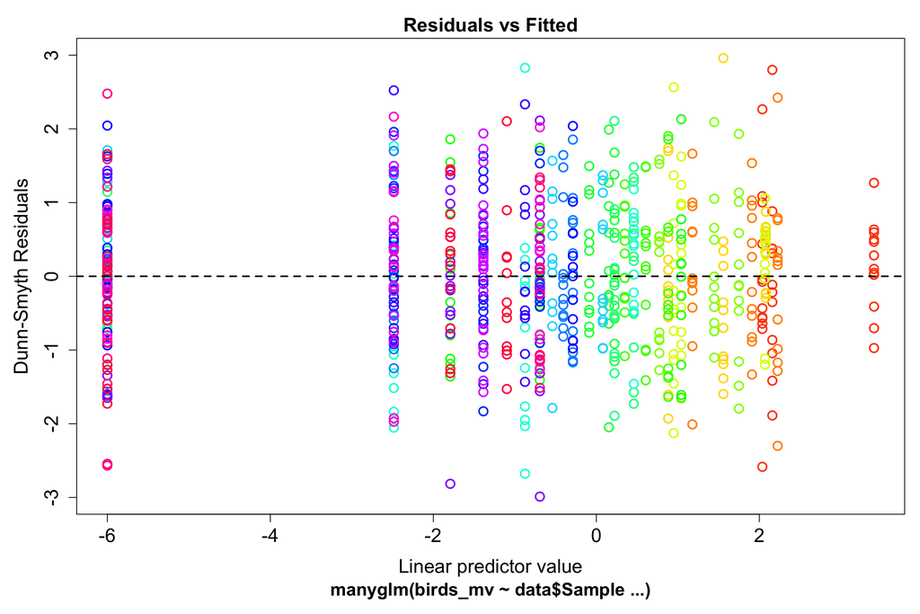

```r
# Plot model residuals
par(mfrow=c(2,2))
plot(mv_sample)
```

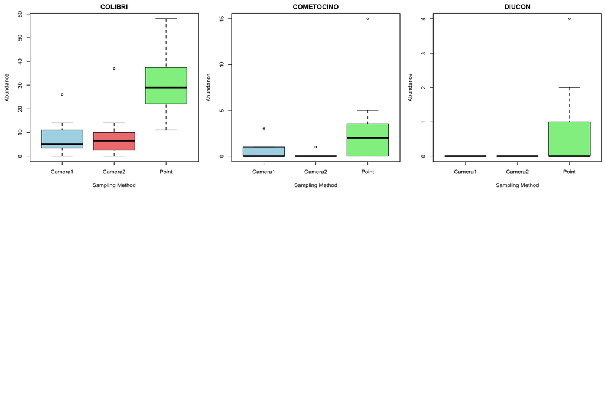

```r
par(mfrow=c(1,1))

# Create abundance plots for significant species
sig_species_names <- species_results$Species[species_results$Significant == "Yes"]

if(length(sig_species_names) > 0) {
  # Select a few species to plot (max 6 for clarity)
  plot_species <- head(sig_species_names, 6)

  par(mfrow=c(2,3))
  for(sp in plot_species) {
    boxplot(birds[,sp] ~ data$Sample,
            main=sp,
            xlab="Sampling Method",
            ylab="Abundance",
            col=c("lightblue", "lightcoral", "lightgreen"))
  }
  par(mfrow=c(1,1))
}
```

## Comparing ANOSIM vs. mvabund Approaches

Let’s summarize and compare the results from both methods:

```r
# Create comparison table
comparison_results <- data.frame(
  Method = c("ANOSIM", "mvabund GLM"),
  Sampling_Method_P = c(
    sampbirds$signif,
    mv_sample_test$table[1,"Pr(>Dev)"]
  ),
  Sampling_Method_Stat = c(
    round(sampbirds$statistic, 3),
    round(mv_sample_test$table[1,"Dev"], 3)
  ),
  Habitat_P = c(
    forestbirds$signif,
    mv_habitat_test$table[1,"Pr(>Dev)"]
  ),
  Habitat_Stat = c(
    round(forestbirds$statistic, 3),
    round(mv_habitat_test$table[1,"Dev"], 3)
  )
)

print("Comparison of Methods:")
```

```
## [1] "Comparison of Methods:"
```

```r
print(comparison_results)
```

```
##        Method Sampling_Method_P Sampling_Method_Stat Habitat_P Habitat_Stat
## 1      ANOSIM             0.001                0.271     0.182        0.035
## 2 mvabund GLM                NA                   NA        NA           NA
```

### When to Use Each Method

**Use ANOSIM/SIMPER when:** - You need a quick, exploratory analysis - Your focus is on dissimilarity/distance-based patterns - You want a simple, non-parametric approach - Sample sizes are very small - You’re primarily interested in overall community patterns

**Use mvabund when:** - You want more statistical power - You need species-level inference with proper p-values - Your data has count structure with overdispersion - You want to account for mean-variance relationships - You need to include covariates or test complex designs - You want model-based inference rather than distance-based

**Key differences:**

| Aspect | ANOSIM | mvabund |
| --- | --- | --- |
| **Approach** | Distance-based, non-parametric | Model-based GLMs |
| **Test statistic** | R (rank-based) | Likelihood ratio |
| **Species inference** | Indirect (via SIMPER) | Direct with adjusted p-values |
| **Mean-variance** | Not explicitly modeled | Explicitly modeled |
| **Power** | Lower | Higher |
| **Assumptions** | Exchangeability | GLM assumptions |
| **Complexity** | Simple | More complex |

### Methodological Considerations

```r
print("Important considerations:")
```

```
## [1] "Important considerations:"
```

```r
print("")
```

```
## [1] ""
```

```r
print("ANOSIM limitations:")
```

```
## [1] "ANOSIM limitations:"
```

```r
print("- Sensitive to differences in dispersion (not just location)")
```

```
## [1] "- Sensitive to differences in dispersion (not just location)"
```

```r
print("- R statistic can be hard to interpret")
```

```
## [1] "- R statistic can be hard to interpret"
```

```r
print("- Less powerful for detecting subtle differences")
```

```
## [1] "- Less powerful for detecting subtle differences"
```

```r
print("- Doesn't provide species-level p-values")
```

```
## [1] "- Doesn't provide species-level p-values"
```

```r
print("")
```

```
## [1] ""
```

```r
print("mvabund advantages:")
```

```
## [1] "mvabund advantages:"
```

```r
print("- More powerful statistical tests")
```

```
## [1] "- More powerful statistical tests"
```

```r
print("- Proper inference at both community and species levels")
```

```
## [1] "- Proper inference at both community and species levels"
```

```r
print("- Accounts for data properties (counts, overdispersion)")
```

```
## [1] "- Accounts for data properties (counts, overdispersion)"
```

```r
print("- Can include covariates and interactions")
```

```
## [1] "- Can include covariates and interactions"
```

```r
print("- Model checking via residual diagnostics")
```

```
## [1] "- Model checking via residual diagnostics"
```

```r
print("")
```

```
## [1] ""
```

```r
print("Best practice: Use both methods for complementary insights!")
```

```
## [1] "Best practice: Use both methods for complementary insights!"
```

## Final thoughts

ANOSIM and SIMPER are simple tests to test for species composition differences and provide an actual hypothesis test with a proper P value. This approach is more appropriate to analyze species composition data rather than other approaches, such as ANOVA, which may be giving unreliable results.

However, **modern best practice** increasingly favors model-based approaches like mvabund because they: - Provide greater statistical power - Allow direct species-level inference - Better account for properties of count data - Enable more complex experimental designs - Provide better control of Type I error rates

### Recommendations for your analyses:

1. **Start with exploratory analysis:** Use ordination (NMDS, PCA) to visualize patterns
2. **Test community-level hypotheses:** Use mvabund for formal testing
3. **Identify key species:** Use species-level tests from mvabund
4. **Validate with ANOSIM:** Use as a complementary non-parametric check
5. **Report both:** When results differ, discuss why (dispersion effects, power differences)

### Additional Resources:

- Wang et al. (2012) “mvabund – an R package for model-based analysis of multivariate abundance data” - Methods in Ecology and Evolution
- Warton et al. (2012) “Distance-based multivariate analyses confound location and dispersion effects” - Methods in Ecology and Evolution
- Warton et al. (2015) “So Many Variables: Joint Modeling in Community Ecology” - Trends in Ecology & Evolution

Licensing Creative Commons License

Licensed under a Creative Commons Attribution-ShareAlike 4.0 International License.  
2026 - Francisco E. Fontúrbel